# 20212_M2_875_PEC1_Enunciado_solucion

[figure not shown]

M2.875 · Deep Learning · PEC1

2021-2 · Máster universitario en Ciencia de datos (Data science)

Estudios de Informática, Multimedia y Telecomunicación

# PEC 1: Redes neuronales artificiales

En esta práctica implementaremos redes neuronales artificiales para resolver problemas de:

- Clasificación
- Regresión

**Importante: La entrega debe hacerse en formato notebook y en formato html donde se vea el código y los resultados y comentarios de cada ejercicio. Para exportar el notebook a html puede hacerse desde el menú File $\to$ Download as $\to$ HTML.**

## 0. Contexto y carga de librerías

El siguiente código carga los paquetes necesarios para la práctica y lee el fichero de datos que usaremos.

Los datos contienen información sobre coches de segunda mano, sus características y el precio de re-venta en euros. En un primer ejercicio diseñaremos un modelo que nos permita clasificar los coches en tres grupos según su gama de precio. En el segundo ejercicio diseñaremos un modelo de regresión para predecir el precio de re-venta.

```python
import pandas as pd
import numpy as np

import matplotlib.pyplot as plt
import seaborn as sns
import timeit

import keras
from keras.models import Sequential, Model
from keras.layers import Dense
from tensorflow.keras.optimizers import Adam, SGD, Adadelta, Adagrad

from sklearn.model_selection import train_test_split
from sklearn.metrics import confusion_matrix, mean_squared_error, classification_report
from sklearn.preprocessing import OneHotEncoder, StandardScaler
```

```python
##To read directly from Drive in Google Colab use:
from google.colab import drive
drive.mount('/content/drive')
#input path: "./drive/MyDrive/CarPricesData.pkl"

##To read in Kaggle, upload file in Kaggle
##input path: "/kaggle/input/botnetdl/botnet_dataset_DL.csv"
```

```python
df = pd.read_csv("./drive/MyDrive/DL/dataset.csv") #change path if needed
```

```python
df.head(5)
```

|  | months_old | km | fuel_type | horsepower | metcolor | automatic | size_engine | doors_num | weight | price |
| --- | --- | --- | --- | --- | --- | --- | --- | --- | --- | --- |
| 0 | 73 | 97494 | Petrol | 110 | 1 | 0 | 1600 | 5 | 1085 | 10950 |
| 1 | 48 | 89049 | Petrol | 97 | 1 | 0 | 1400 | 5 | 1060 | 13500 |
| 2 | 40 | 161000 | Diesel | 69 | 1 | 0 | 1900 | 3 | 1105 | 13950 |
| 3 | 37 | 38812 | Petrol | 97 | 0 | 0 | 1400 | 3 | 1025 | 13450 |
| 4 | 55 | 33230 | Petrol | 110 | 0 | 0 | 1600 | 3 | 1050 | 13500 |

## 1. Exploración (1 punto)

En primer lugar exploraremos el conjunto de datos.

**Ejercicio (1 punto):** Explora los datos:

- Indica el tamaño del dataset y el número de variables categóricas y continuas del conjunto de datos
- Grafica las distribuciones de las variables categóricas y de las continuas
- Genera una tabla de correlaciones de todas las variables usando la librería `seaborn`, mostrando en cada casilla el valor de la correlación
- Genera una tabla (usando la librería `seaborn`) que muestre únicamente las correlaciones entre el precio y el resto de variables, ordenada de mayor a menor según los valores de correlación
- Comenta los resultados de la exploración de datos
- **Variables**

```python
#Dataset size
df.shape
```

```
(1436, 10)
```

```python
#Number of categorical and continuous variables
num_categorical_variables = 6
num_continuous_variables = 4
```

- **Distribuciones**

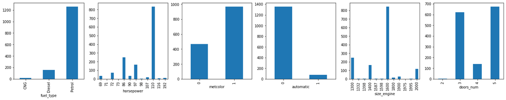

```python
#Distributions of categorical variables
 fig, ax = plt.subplots(nrows=1, ncols=num_categorical_variables, figsize=(25,4))
 for colName, plotNumber in zip(['fuel_type', 'horsepower', 'metcolor', 'automatic', 'size_engine', 'doors_num'], range(num_categorical_variables)):
   df.groupby(colName).size().plot(kind='bar',ax=ax[plotNumber])
```

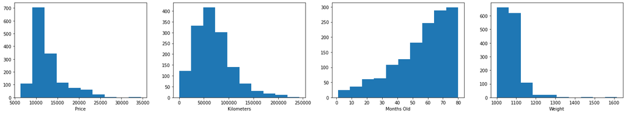

```python
#Distributions continuous variables
fig, ax = plt.subplots(nrows=1, ncols=num_continuous_variables, figsize=(25,4))
ax[0].hist(df['price'])
ax[0].set_xlabel("Price")
ax[1].hist(df['km'])
ax[1].set_xlabel("Kilometers")
ax[2].hist(df['months_old'])
ax[2].set_xlabel("Months Old")
ax[3].hist(df['weight'])
ax[3].set_xlabel("Weight")
```

- **Correlaciones**

```python
#transform fuel_type to numeric
conditions = [
    df['fuel_type']=="Petrol",
    df['fuel_type']=="Diesel",
    df['fuel_type']=="CNG"
]

choices = [0,1,2]

df['fuel_type'] = np.select(conditions, choices, default=0)
```

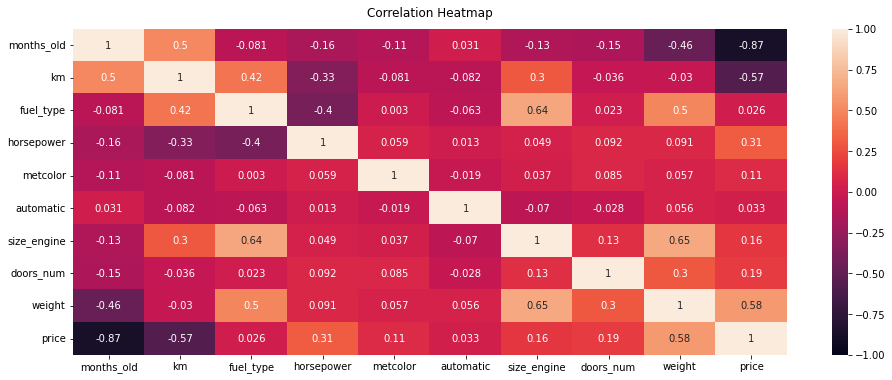

```python
#All variables correlations
plt.figure(figsize=(16, 6))
heatmap = sns.heatmap(df.corr(), vmin=-1, vmax=1, annot=True) #valores de correlación
heatmap.set_title('Correlation Heatmap', fontdict={'fontsize':12}, pad=12);
```

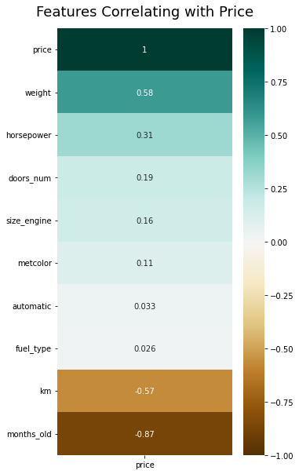

```python
#Features correlating with Price
plt.figure(figsize=(5, 10))
heatmap = sns.heatmap(df.corr()[['price']].sort_values(by='price', ascending=False), vmin=-1, vmax=1, annot=True, cmap='BrBG')
heatmap.set_title('Features Correlating with Price', fontdict={'fontsize':18}, pad=16);
```

- **Comentarios resultado exploración**

## 2. Red neuronal artificial: Clasificación (4.5 puntos)

En este apartado entrenaremos un modelo que intente clasificar los coches según su gama de precio. Para ello crearemos una nueva variable como indicador de calidad del coche (gama baja, media o alta), siguiendo las siguientes condiciones:

- *low-end*: precio menor que 11000 euros
- *medium-end*: precio mayor o igual que 11000 euros y menor que 13000
- *high-end*: precio mayor o igual que 13000

### Pre-procesado

**Ejercicio (0.75 puntos):** Pre-procesa los datos:

- Crea una nueva variable `quality` que incluya la gama del coche, con las condiciones indicadas
- Muestra el histograma de la nueva variable `quality`
- Crea los vectores de variables dependientes (*features*) y de la variable independiente (*labels*)
- Normaliza debidamente los datos y binariza el vector de etiquetas (*labels*)
- Divide el conjunto de datos en 80% para entrenamiento y 20% para test, usando la función `train_test_split`
- Muestra las dimensiones de los conjuntos de entrenamiento y test

```python
#Create new variable: quality
conditions = [
    (df['price']<11000),
    (df['price']>=11000) & (df['price']<13000),
    (df['price']>=13000)]
choices = ['low-end','medium-end','high-end']
df['quality'] = np.select(conditions, choices, default='none')
```

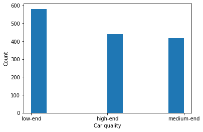

```python
#Histogram car quality
plt.hist(df['quality'])
plt.xlabel('Car quality')
plt.ylabel('Count')
```

```python
#Changing pandas dataframe to numpy array
features = df.iloc[:,:10].values
labels = df.iloc[:,10:11].values #Price
```

```python
#Normalizing the data
sc = StandardScaler()
features = sc.fit_transform(features)
```

```python
#Onehot encode the target
ohe = OneHotEncoder()
labels = ohe.fit_transform(labels).toarray()
```

```python
#SPLIT
train_x, test_x, train_y, test_y = train_test_split(features, labels, test_size=0.2)
```

```python
#SHAPES
print(train_x.shape)
print(train_y.shape)
print(test_x.shape)
print(test_y.shape)
```

```
(1148, 10)
(1148, 3)
(288, 10)
(288, 3)
```

### Modelo base

Empezaremos diseñando un modelo base con 4 capas ocultas.

Nota: Para el ajuste del modelo usaremos los datos de test como conjunto de validación.

**Ejercicio (1.25 puntos):** Implementa el modelo de red neuronal artificial:

- Diseña la arquitectura para el modelo de clasificación con la función de activación adecuada para la capa de salida y con las siguientes características:
- 4 capas ocultas con 64, 32, 10, 8 neuronas sucesivamente
- Función de activación de las capas intermedias: ReLU
- Compila el modelo con la función de pérdida más adecuada, el optimizador Adam, una velocidad de aprendizaje de 0.1, y la métrica Accuracy.
- Ajusta el modelo con 20 épocas y un tamaño del batch de 64
- Muestra las gráficas de accuracy y loss. En cada gráfica debe visualizarse la curva de entrenamiento y la de validación

```python
#Create ANN model
model = Sequential()
model.add(Dense(64, input_dim=train_x.shape[1], activation='relu'))
model.add(Dense(32, activation='relu'))
model.add(Dense(10, activation='relu'))
model.add(Dense(8, activation='relu'))
model.add(Dense(labels.shape[1],activation='softmax'))

#Compile
model.compile(loss='categorical_crossentropy', optimizer=Adam(lr=0.1), metrics=['accuracy'])

#Fit
history = model.fit(train_x, train_y,
                    validation_data=(test_x, test_y),
                    epochs=20,
                    batch_size=64)
```

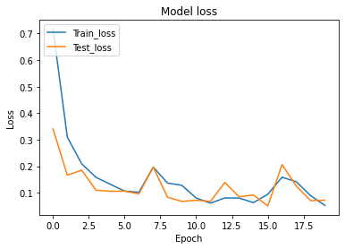

```python
#LOSS PLOT
def loss_plot(history):
    plt.plot(history.history['loss'])
    plt.plot(history.history['val_loss'])
    plt.title('Model loss')
    plt.ylabel('Loss')
    plt.xlabel('Epoch')
    plt.legend(['Train_loss', 'Test_loss'], loc='upper left')
    plt.show()

loss_plot(history)
```

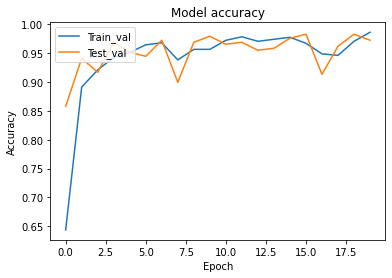

```python
#Accuracy plot
def acc_plot(history):
    plt.plot(history.history['accuracy'])
    plt.plot(history.history['val_accuracy'])
    plt.title('Model accuracy')
    plt.ylabel('Accuracy')
    plt.xlabel('Epoch')
    plt.legend(['Train_val', 'Test_val'], loc='upper left')
    plt.show()

acc_plot(history)
```

### Influencia velocidad aprendizaje y optimizador

Una vez tenemos el modelo base, analizaremos la influencia que pueden tener la velocidad de aprendizaje y el tipo de optimizador en la mejora del rendimiento.

**Ejercicio (1.5 puntos):** Implementa una función para entrenar la arquitectura del ejercicio anterior para 4 optimizadores diferentes: Adam, SGD, Adadelta, Adagrad, y 4 velocidades de aprendizaje: 0.001, 0.01, 0.05, 0.1. Entrena los modelos, y representa dos gráficas:

- Tiempo de entrenamiento vs Velocidad de aprendizaje
- *Accuracy* vs Velocidad de aprendizaje

Cada gráfica debe incluir la evolución obtenida por los cuatro optimizadores para poderlos comparar mejor. ----------------------------------------------------------------------------------------------------------- **Importante**: para la entrega de la PEC, fijar el parámetro `verbose = 0` en el entrenamiento de los modelos. La solución únicamente debe mostrar las gráficas resultantes.

```python
def modelLrOpt(opt, lrate):
    acc = []
    t = []
    for lr in lrate:
        model = Sequential()
        model.add(Dense(128, input_dim=train_x.shape[1], activation='relu'))
        model.add(Dense(64, activation='relu'))
        model.add(Dense(32, activation='relu'))
        model.add(Dense(16, activation='relu'))
        model.add(Dense(labels.shape[1],activation='softmax'))
        model.compile(loss='categorical_crossentropy', optimizer=opt(learning_rate=lr), metrics=['accuracy'])
        start_time = timeit.default_timer()
        history = model.fit(train_x, train_y,validation_data=(test_x, test_y),epochs=20, batch_size=32, verbose=0)
        t.append(timeit.default_timer() - start_time)
        acc.append(model.evaluate(test_x, test_y, verbose=0)[1])

    return history, model, t, acc
```

```python
lr = [0.001,0.01,0.05,0.1]
print("Training Adam models...")
histAdam, modAdam, tAdam, accAdam = modelLrOpt(Adam, lr)
print("Training SGD models...")
histSGD, modSGD, tSGD, accSGD = modelLrOpt(SGD, lr)
print("Training Adadelta models...")
histAdadelta, modAdadelta, tAdadelta, accAdadelta = modelLrOpt(Adadelta, lr)
print("Training Adagrad models...")
histAdagrad, modAdagrad, tAdagrad, accAdagrad = modelLrOpt(Adagrad, lr)
```

```
Training Adam models...
Training SGD models...
Training Adadelta models...
Training Adagrad models...
```

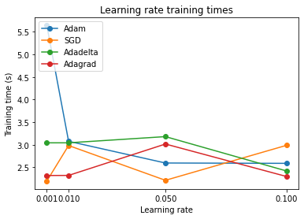

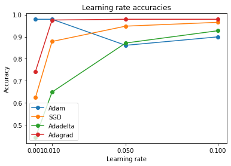

```python
#PLOTS
lr = [0.001, 0.01, 0.05, 0.1]
plt.plot(lr, tAdam, marker="o")
plt.plot(lr, tSGD, marker="o")
plt.plot(lr, tAdadelta, marker="o")
plt.plot(lr, tAdagrad, marker="o")
plt.title('Learning rate training times')
plt.ylabel('Training time (s)')
plt.xlabel('Learning rate')
plt.xticks(lr)
plt.legend(['Adam', 'SGD', 'Adadelta', 'Adagrad'], loc='upper left')
plt.show()


lr = [0.001, 0.01, 0.05, 0.1]
plt.plot(lr, accAdam, marker="o")
plt.plot(lr, accSGD, marker="o")
plt.plot(lr, accAdadelta, marker="o")
plt.plot(lr, accAdagrad, marker="o")
plt.title('Learning rate accuracies')
plt.ylabel('Accuracy')
plt.xlabel('Learning rate')
plt.xticks(lr)
plt.legend(['Adam', 'SGD', 'Adadelta', 'Adagrad'], loc='lower left')
plt.show()
```

### Elección del mejor modelo

**Ejercicio (1 punto):** Identifica el valor de la velocidad de aprendizaje y del optimizador que mejor rendimiento dan al modelo, según los resultados del ejercicio anterior:

- Justifica la elección
- Compila y entrena el modelo elegido
- Muestra las correspondientes gráficas de *Accuracy* y *Loss* de los conjuntos de entrenamiento y validación, e indica el *Accuracy* del modelo
- Muestra la matriz de confusión multi-clase con las etiquetas originales de `quality` (*low-end*, *medium-end*, *high-end*)
- Muestra la precisión, recall y F1-score resultantes para cada etiqueta
- Comenta los resultados obtenidos

```python
#Best model justification
```

```python
#Create ANN BEST model
model = Sequential()
model.add(Dense(64, input_dim=train_x.shape[1], activation='relu'))
model.add(Dense(32, activation='relu'))
model.add(Dense(10, activation='relu'))
model.add(Dense(8, activation='relu'))
model.add(Dense(labels.shape[1],activation='softmax'))

#Compile
model.compile(loss='categorical_crossentropy', optimizer=Adam(lr=0.01), metrics=['accuracy'])

#Fit
history = model.fit(train_x, train_y,
                    validation_data=(test_x, test_y),
                    epochs=20,
                    batch_size=64)
```

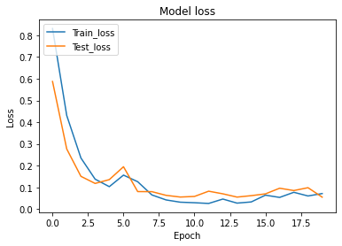

```python
#Loss
loss_plot(history)
```

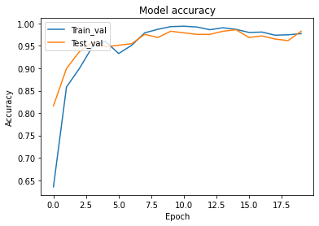

```python
#Accuracy
acc_plot(history)
```

```python
#Confusion matrix
import itertools

def plot_confusion_matrix(cm, classes, normalize=False, title='Confusion matrix', cmap=plt.cm.Blues):
    """
    This function prints and plots the confusion matrix.
    Normalization can be applied by setting `normalize=True`.
    """
    plt.imshow(cm, interpolation='nearest', cmap=cmap)
    plt.title(title)
    plt.colorbar()
    tick_marks = np.arange(len(classes))
    plt.xticks(tick_marks, classes, rotation=0)
    plt.yticks(tick_marks, classes)

    if normalize:
        cm = cm.astype('float') / cm.sum(axis=1)[:, np.newaxis]
    else:
        1

    thresh = cm.max() / 2.
    for i, j in itertools.product(range(cm.shape[0]), range(cm.shape[1])):
        plt.text(j, i, cm[i, j],
                 horizontalalignment="center",
                 color="white" if cm[i, j] > thresh else "black")

    plt.tight_layout()
    plt.ylabel('True label')
    plt.xlabel('Predicted label')
```

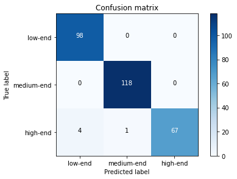

```python
pred = model.predict(test_x)
cm = confusion_matrix(test_y.argmax(axis=1), pred.argmax(axis=1))
np.set_printoptions(precision=2)
class_names = ['low-end','medium-end', 'high-end']
plt.figure()
plot_confusion_matrix(cm, classes=class_names, title='Confusion matrix')
plt.show()
```

```python
#Accuracy
model.evaluate(test_x, test_y, verbose=0)[1]
```

```
0.9826388955116272
```

```python
#Precision, Recall and F1-score for each label
print(classification_report(test_y.argmax(axis=1), pred.argmax(axis=1), target_names=['low_end','medium-end', 'high-end']))
```

```
              precision    recall  f1-score   support

     low_end       0.96      1.00      0.98        98
  medium-end       0.99      1.00      1.00       118
    high-end       1.00      0.93      0.96        72

    accuracy                           0.98       288
   macro avg       0.98      0.98      0.98       288
weighted avg       0.98      0.98      0.98       288
```

```python
#Comment results
```

## 3. Red neuronal artificial: Regresión (4.5 puntos)

En este apartado resolveremos un problema de regresión intentando predecir el precio de re-venta según las características de los coches. Partiremos del conjunto de datos original.

### Pre-procesado

**Ejercicio (0.5 puntos):** Pre-procesa los datos:

- Crea los vectores de variables dependientes (*features*) y de la variable independiente (*target*)
- Normaliza debidamente los datos
- Divide el conjunto de datos en 70% para entrenamiento y 30% para test, usando la función `train_test_split`
- Muestra las dimensiones de los conjuntos de entrenamiento y test

```python
#Changing pandas dataframe to numpy array
features = df.iloc[:,:9].values
target = df.iloc[:,9:10].values #Price
```

```python
#Normalizing the data
from sklearn.preprocessing import StandardScaler
sc = StandardScaler()
features = sc.fit_transform(features)
target = sc.fit_transform(target)
```

```python
#Split train-test
train_x, test_x, train_y, test_y = train_test_split(features, target, test_size=0.3)
```

```python
#Dimensions
print(train_x.shape)
print(train_y.shape)
print(test_x.shape)
print(test_y.shape)
```

```
(1005, 9)
(1005, 1)
(431, 9)
(431, 1)
```

### Modelo base

En primer lugar diseñaremos un modelo base con tres capas ocultas.

Nota: Para el ajuste del modelo usaremos los datos de test como conjunto de validación.

**Ejercicio (1 punto):** Implementa el modelo de red neuronal artificial:

- Diseña la arquitectura para el modelo de regresión con las siguientes características:
- 1 primera capa oculta completamente conectada de 128 neuronas y activación ReLU
- 2 capas ocultas de 32 y 16 neuronas y activación tangencial
- Todas las capas deben tener `kernel_initizalizer` en modo 'normal'
- Compila el modelo con la función de pérdida más adecuada y el optimizador Adam
- Ajusta el modelo con 50 épocas y un tamaño del batch de 32
- Muestra la gráfica de pérdida. En la gráfica debe visualizarse la curva de entrenamiento y la de validación

```python
# Create ANN model
model = Sequential()
model.add(Dense(units=128, input_dim=train_x.shape[1], kernel_initializer='normal', activation='relu'))
model.add(Dense(units=32, kernel_initializer='normal', activation='tanh'))
model.add(Dense(units=16, kernel_initializer='normal', activation='tanh'))
model.add(Dense(1, kernel_initializer='normal'))

# Compiling the model
model.compile(loss='mean_squared_error', optimizer='adam')

# Fit model
history = model.fit(train_x, train_y ,validation_data=(test_x, test_y),batch_size = 32, epochs = 50, verbose=1)  ###ADD VALIDATION DATA
```

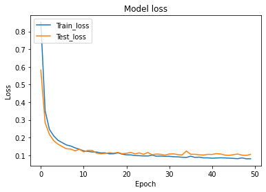

```python
#Loss plot
loss_plot (history)
```

### Búsqueda hiperparámetros

Una vez tenemos el modelo base nos interesa buscar la configuración de hiperparámetros que nos proporcione una mejor predicción del precio de re-venta de los coches. En este apartado haremos una búsqueda de hiperparámetros, recorriendo varios valores de número de capas, número de neuronas, tamaño del batch y épocas.

**Ejercicio (1.75 puntos):** Implementa una función que evalúe distintos modelos combinando las siguientes características:

- Tres arquitecturas diferentes con las siguientes configuraciones de número de capas ocultas (completamente conectadas) y número de neuronas en cada capa:
- [128, 64, 16]
- [16, 4]
- [4, 4]
- Tamaño del batch de 16 y 32
- Épocas de 20, 50 y 100

Como en el ejercicio anterior, la primera capa oculta tendrá siempre activación ReLU y las demás activación tangencial. El inicializador de kernel estará en modo 'normal' y usaremos el optimizador Adam. La función deberá proporcionar una tabla con los siguientes campos: arquitectura de la red seleccionada, épocas, tamaño del batch, tiempo de entrenamiento, y raíz del error cuadrático medio (RMSE) del modelo ----------------------------------------------------------------------------------------------------------- **Importante**: para la entrega de la PEC, fijar el parámetro `verbose = 0` en el entrenamiento de los modelos. La solución únicamente debe mostrar la tabla resultante.

```python
def main_model(layers_dims):
    L = len(layers_dims)

    model = Sequential()

    for l in range(1, L):
        if l == 1:
            # Capa de entrada
            model.add(Dense(layers_dims[l], input_dim = layers_dims[0], kernel_initializer='normal',activation = 'relu'))
        elif l == L - 1:
            # Última capa
            model.add(Dense(layers_dims[l], kernel_initializer='normal'))  ##NO ACTIVATION IN REGRESSION!
        else:
            # Capas ocultas
            model.add(Dense(layers_dims[l], kernel_initializer='normal', activation = 'tanh'))

    model.compile(loss='mean_squared_error', optimizer='adam')

    return model


def gridSearchKeras(train_x, train_y, test_x, test_y, layers_dims, epochs, batch_size):
    nn_df_columns = {"Configuration":[], "Network architecture": [], "Epochs": [], "Batch size": [], "Time": [], "RMSE": []}
    num=0
    for l in layers_dims:
      for e in epochs:
        for b in batch_size:
          start_time = timeit.default_timer()

          model = main_model(layers_dims=l)
          model.fit(train_x, train_y, validation_data=(test_x, test_y), epochs=e, batch_size=b, verbose=0)

          rmse = np.sqrt(mean_squared_error(test_y,model.predict(test_x)))

          elapsed = timeit.default_timer() - start_time

          nn_df_columns['Configuration'].append(num)
          nn_df_columns['Network architecture'].append(l)
          nn_df_columns['Epochs'].append(e)
          nn_df_columns['Batch size'].append(b)
          nn_df_columns['Time'].append(elapsed)
          nn_df_columns['RMSE'].append(rmse)

          num+=1
    return pd.DataFrame(nn_df_columns)
```

```python
#Compute search
layers_dims = [[9, 128, 64, 16, 1], [9, 16, 4, 1], [9, 4, 4, 1]]
epochs = [20, 50, 100]
batch_size = [16,32]

res = gridSearchKeras(train_x, train_y, test_x, test_y, layers_dims, epochs, batch_size)
res
```

|  | Configuration | Network architecture | Epochs | Batch size | Time | RMSE |
| --- | --- | --- | --- | --- | --- | --- |
| 0 | 0 | [9, 128, 64, 16, 1] | 20 | 16 | 3.983405 | 0.329338 |
| 1 | 1 | [9, 128, 64, 16, 1] | 20 | 32 | 2.513128 | 0.340761 |
| 2 | 2 | [9, 128, 64, 16, 1] | 50 | 16 | 10.830100 | 0.318948 |
| 3 | 3 | [9, 128, 64, 16, 1] | 50 | 32 | 5.727832 | 0.317492 |
| 4 | 4 | [9, 128, 64, 16, 1] | 100 | 16 | 21.066969 | 0.320509 |
| 5 | 5 | [9, 128, 64, 16, 1] | 100 | 32 | 9.503724 | 0.319040 |
| 6 | 6 | [9, 16, 4, 1] | 20 | 16 | 3.183010 | 0.362441 |
| 7 | 7 | [9, 16, 4, 1] | 20 | 32 | 3.093071 | 0.404688 |
| 8 | 8 | [9, 16, 4, 1] | 50 | 16 | 7.254628 | 0.321144 |
| 9 | 9 | [9, 16, 4, 1] | 50 | 32 | 5.664249 | 0.332931 |
| 10 | 10 | [9, 16, 4, 1] | 100 | 16 | 21.061306 | 0.316406 |
| 11 | 11 | [9, 16, 4, 1] | 100 | 32 | 8.036972 | 0.326675 |
| 12 | 12 | [9, 4, 4, 1] | 20 | 16 | 3.264678 | 0.359723 |
| 13 | 13 | [9, 4, 4, 1] | 20 | 32 | 2.182571 | 0.421382 |
| 14 | 14 | [9, 4, 4, 1] | 50 | 16 | 10.778768 | 0.340388 |
| 15 | 15 | [9, 4, 4, 1] | 50 | 32 | 5.675205 | 0.330065 |
| 16 | 16 | [9, 4, 4, 1] | 100 | 16 | 13.876297 | 0.323624 |
| 17 | 17 | [9, 4, 4, 1] | 100 | 32 | 8.653035 | 0.324043 |

**Ejercicio (0.25 puntos):** Representa en un gráfico el RMSE vs la configuración de los modelos

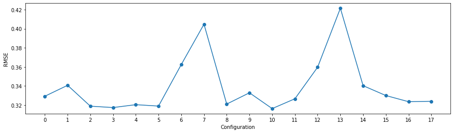

```python
#Plot
%matplotlib inline
plt.figure(figsize=(15,4))
plt.plot(res['Configuration'], res['RMSE'], marker="o")
plt.ylabel('RMSE')
plt.xlabel('Configuration')
plt.xticks(res['Configuration'])
plt.show()
```

### Elección mejor modelo y predicción

**Ejercicio (1 punto):** Identifica la configuración que proporciona mejores resultados:

- Justifica la elección del modelo
- Compila y entrena el modelo elegido. Nota: para la entrega, presentar con verbose=0
- Muestra la correspondiente gráfica de pérdida de los conjuntos de entrenamiento y validación
- Calcula las predicciones del precio y muestra en una tabla el Precio original (`price`) y el Precio predicho (`predicted_price`) para las 10 primeras filas del conjunto de test
- Comenta los resultados obtenidos

```python
#Best configuration justification
#El que da menor RMSE
```

```python
# Create, compile and fit ANN best model
model = Sequential()
model.add(Dense(units=16, input_dim=train_x.shape[1], kernel_initializer='normal', activation='relu'))
model.add(Dense(units=4, kernel_initializer='normal', activation='tanh'))
model.add(Dense(1, kernel_initializer='normal'))

# Compiling the model
model.compile(loss='mean_squared_error', optimizer='adam')

history = model.fit(train_x, train_y ,validation_data=(test_x, test_y), batch_size = 16, epochs = 100, verbose=0)
```

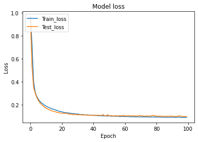

```python
#Loss plot
loss_plot(history)
```

```python
# Generating Predictions on testing data
pred=model.predict(test_x)

# Scaling the predicted Price data back to original price scale
pred=sc.inverse_transform(pred)

# Scaling the y_test Price data back to original price scale
y_test_orig=sc.inverse_transform(test_y)

## Scaling the test data back to original scale
#x_test_orig=sc.inverse_transform(test_x)

test_res=pd.DataFrame(index=range(len(y_test_orig)),columns=range(0))
test_res['price']=y_test_orig
test_res['predicted_price']=pred
test_res.head(10)
```

|  | price | predicted_price |
| --- | --- | --- |
| 0 | 18500.0 | 19580.468750 |
| 1 | 13250.0 | 14407.257812 |
| 2 | 11950.0 | 11880.875000 |
| 3 | 12950.0 | 13012.132812 |
| 4 | 13950.0 | 12590.757812 |
| 5 | 8900.0 | 10050.922852 |
| 6 | 12950.0 | 12262.353516 |
| 7 | 22750.0 | 21108.767578 |
| 8 | 14450.0 | 15449.531250 |
| 9 | 13950.0 | 14466.397461 |

```python
#Comment results
```